# Exit Surveys - DETE & TAFE

### Analysing the Department of Education, Training and Employment (DETE) and the Technical and Further Education (TAFE) exit surveys, and trying to answer questions such as:

```
- Are employees who only worked for the institutes for a short period of time resigning due to some kind of dissatisfaction? What about employees who have been there longer?
- Are younger employees resigning due to some kind of dissatisfaction? What about older employees?
```

### The aim of the project is to try to grasp the reasons for the non retention of employees in order to better counter this trend.

### For that we will rely in 2 very similar DataSet's, one from DETE and the other one from TAFE.

```python
import pandas as pd
import numpy as np
import matplotlib.pyplot as plt
%matplotlib inline
```

```python
dete_survey = pd.read_csv('dete_survey.csv')
tafe_survey = pd.read_csv('tafe_survey.csv')
```

```python
dete_survey.info()
dete_survey.head()
```

```
<class 'pandas.core.frame.DataFrame'>
RangeIndex: 822 entries, 0 to 821
Data columns (total 56 columns):
ID                                     822 non-null int64
SeparationType                         822 non-null object
Cease Date                             822 non-null object
DETE Start Date                        822 non-null object
Role Start Date                        822 non-null object
Position                               817 non-null object
Classification                         455 non-null object
Region                                 822 non-null object
Business Unit                          126 non-null object
Employment Status                      817 non-null object
Career move to public sector           822 non-null bool
Career move to private sector          822 non-null bool
Interpersonal conflicts                822 non-null bool
Job dissatisfaction                    822 non-null bool
Dissatisfaction with the department    822 non-null bool
Physical work environment              822 non-null bool
Lack of recognition                    822 non-null bool
Lack of job security                   822 non-null bool
Work location                          822 non-null bool
Employment conditions                  822 non-null bool
Maternity/family                       822 non-null bool
Relocation                             822 non-null bool
Study/Travel                           822 non-null bool
Ill Health                             822 non-null bool
Traumatic incident                     822 non-null bool
Work life balance                      822 non-null bool
Workload                               822 non-null bool
None of the above                      822 non-null bool
Professional Development               808 non-null object
Opportunities for promotion            735 non-null object
Staff morale                           816 non-null object
Workplace issue                        788 non-null object
Physical environment                   817 non-null object
Worklife balance                       815 non-null object
Stress and pressure support            810 non-null object
Performance of supervisor              813 non-null object
Peer support                           812 non-null object
Initiative                             813 non-null object
Skills                                 811 non-null object
Coach                                  767 non-null object
Career Aspirations                     746 non-null object
Feedback                               792 non-null object
Further PD                             768 non-null object
Communication                          814 non-null object
My say                                 812 non-null object
Information                            816 non-null object
Kept informed                          813 non-null object
Wellness programs                      766 non-null object
Health & Safety                        793 non-null object
Gender                                 798 non-null object
Age                                    811 non-null object
Aboriginal                             16 non-null object
Torres Strait                          3 non-null object
South Sea                              7 non-null object
Disability                             23 non-null object
NESB                                   32 non-null object
dtypes: bool(18), int64(1), object(37)
memory usage: 258.6+ KB
```

|  | ID | SeparationType | Cease Date | DETE Start Date | Role Start Date | Position | Classification | Region | Business Unit | Employment Status | ... | Kept informed | Wellness programs | Health & Safety | Gender | Age | Aboriginal | Torres Strait | South Sea | Disability | NESB |
| --- | --- | --- | --- | --- | --- | --- | --- | --- | --- | --- | --- | --- | --- | --- | --- | --- | --- | --- | --- | --- | --- |
| 0 | 1 | Ill Health Retirement | 08/2012 | 1984 | 2004 | Public Servant | A01-A04 | Central Office | Corporate Strategy and Peformance | Permanent Full-time | ... | N | N | N | Male | 56-60 | NaN | NaN | NaN | NaN | Yes |
| 1 | 2 | Voluntary Early Retirement (VER) | 08/2012 | Not Stated | Not Stated | Public Servant | AO5-AO7 | Central Office | Corporate Strategy and Peformance | Permanent Full-time | ... | N | N | N | Male | 56-60 | NaN | NaN | NaN | NaN | NaN |
| 2 | 3 | Voluntary Early Retirement (VER) | 05/2012 | 2011 | 2011 | Schools Officer | NaN | Central Office | Education Queensland | Permanent Full-time | ... | N | N | N | Male | 61 or older | NaN | NaN | NaN | NaN | NaN |
| 3 | 4 | Resignation-Other reasons | 05/2012 | 2005 | 2006 | Teacher | Primary | Central Queensland | NaN | Permanent Full-time | ... | A | N | A | Female | 36-40 | NaN | NaN | NaN | NaN | NaN |
| 4 | 5 | Age Retirement | 05/2012 | 1970 | 1989 | Head of Curriculum/Head of Special Education | NaN | South East | NaN | Permanent Full-time | ... | N | A | M | Female | 61 or older | NaN | NaN | NaN | NaN | NaN |

5 rows × 56 columns

```python
tafe_survey.info()
tafe_survey.head()
```

```
<class 'pandas.core.frame.DataFrame'>
RangeIndex: 702 entries, 0 to 701
Data columns (total 72 columns):
Record ID                                                                                                                                                        702 non-null float64
Institute                                                                                                                                                        702 non-null object
WorkArea                                                                                                                                                         702 non-null object
CESSATION YEAR                                                                                                                                                   695 non-null float64
Reason for ceasing employment                                                                                                                                    701 non-null object
Contributing Factors. Career Move - Public Sector                                                                                                                437 non-null object
Contributing Factors. Career Move - Private Sector                                                                                                               437 non-null object
Contributing Factors. Career Move - Self-employment                                                                                                              437 non-null object
Contributing Factors. Ill Health                                                                                                                                 437 non-null object
Contributing Factors. Maternity/Family                                                                                                                           437 non-null object
Contributing Factors. Dissatisfaction                                                                                                                            437 non-null object
Contributing Factors. Job Dissatisfaction                                                                                                                        437 non-null object
Contributing Factors. Interpersonal Conflict                                                                                                                     437 non-null object
Contributing Factors. Study                                                                                                                                      437 non-null object
Contributing Factors. Travel                                                                                                                                     437 non-null object
Contributing Factors. Other                                                                                                                                      437 non-null object
Contributing Factors. NONE                                                                                                                                       437 non-null object
Main Factor. Which of these was the main factor for leaving?                                                                                                     113 non-null object
InstituteViews. Topic:1. I feel the senior leadership had a clear vision and direction                                                                           608 non-null object
InstituteViews. Topic:2. I was given access to skills training to help me do my job better                                                                       613 non-null object
InstituteViews. Topic:3. I was given adequate opportunities for personal development                                                                             610 non-null object
InstituteViews. Topic:4. I was given adequate opportunities for promotion within %Institute]Q25LBL%                                                              608 non-null object
InstituteViews. Topic:5. I felt the salary for the job was right for the responsibilities I had                                                                  615 non-null object
```

[output cut: 51 more lines]

|  | Record ID | Institute | WorkArea | CESSATION YEAR | Reason for ceasing employment | Contributing Factors. Career Move - Public Sector | Contributing Factors. Career Move - Private Sector | Contributing Factors. Career Move - Self-employment | Contributing Factors. Ill Health | Contributing Factors. Maternity/Family | ... | Workplace. Topic:Does your workplace promote a work culture free from all forms of unlawful discrimination? | Workplace. Topic:Does your workplace promote and practice the principles of employment equity? | Workplace. Topic:Does your workplace value the diversity of its employees? | Workplace. Topic:Would you recommend the Institute as an employer to others? | Gender. What is your Gender? | CurrentAge. Current Age | Employment Type. Employment Type | Classification. Classification | LengthofServiceOverall. Overall Length of Service at Institute (in years) | LengthofServiceCurrent. Length of Service at current workplace (in years) |
| --- | --- | --- | --- | --- | --- | --- | --- | --- | --- | --- | --- | --- | --- | --- | --- | --- | --- | --- | --- | --- | --- |
| 0 | 6.341330e+17 | Southern Queensland Institute of TAFE | Non-Delivery (corporate) | 2010.0 | Contract Expired | NaN | NaN | NaN | NaN | NaN | ... | Yes | Yes | Yes | Yes | Female | 26 30 | Temporary Full-time | Administration (AO) | 1-2 | 1-2 |
| 1 | 6.341337e+17 | Mount Isa Institute of TAFE | Non-Delivery (corporate) | 2010.0 | Retirement | - | - | - | - | - | ... | Yes | Yes | Yes | Yes | NaN | NaN | NaN | NaN | NaN | NaN |
| 2 | 6.341388e+17 | Mount Isa Institute of TAFE | Delivery (teaching) | 2010.0 | Retirement | - | - | - | - | - | ... | Yes | Yes | Yes | Yes | NaN | NaN | NaN | NaN | NaN | NaN |
| 3 | 6.341399e+17 | Mount Isa Institute of TAFE | Non-Delivery (corporate) | 2010.0 | Resignation | - | - | - | - | - | ... | Yes | Yes | Yes | Yes | NaN | NaN | NaN | NaN | NaN | NaN |
| 4 | 6.341466e+17 | Southern Queensland Institute of TAFE | Delivery (teaching) | 2010.0 | Resignation | - | Career Move - Private Sector | - | - | - | ... | Yes | Yes | Yes | Yes | Male | 41 45 | Permanent Full-time | Teacher (including LVT) | 3-4 | 3-4 |

5 rows × 72 columns

```python
dete_survey.isnull().sum().sort_values()
```

```
ID                                       0
Workload                                 0
Work life balance                        0
Traumatic incident                       0
Ill Health                               0
Study/Travel                             0
Relocation                               0
Maternity/family                         0
Employment conditions                    0
Work location                            0
Lack of job security                     0
Lack of recognition                      0
Physical work environment                0
Dissatisfaction with the department      0
None of the above                        0
Interpersonal conflicts                  0
Job dissatisfaction                      0
SeparationType                           0
Cease Date                               0
DETE Start Date                          0
Role Start Date                          0
Career move to public sector             0
Career move to private sector            0
Region                                   0
Position                                 5
Employment Status                        5
Physical environment                     5
Information                              6
Staff morale                             6
Worklife balance                         7
Communication                            8
Kept informed                            9
Initiative                               9
Performance of supervisor                9
My say                                  10
Peer support                            10
Age                                     11
Skills                                  11
Stress and pressure support             12
Professional Development                14
Gender                                  24
Health & Safety                         29
Feedback                                30
Workplace issue                         34
Further PD                              54
Coach                                   55
Wellness programs                       56
Career Aspirations                      76
Opportunities for promotion             87
Classification                         367
Business Unit                          696
NESB                                   790
Disability                             799
Aboriginal                             806
South Sea                              815
Torres Strait                          819
dtype: int64
```

```python
dete_survey['Aboriginal'].value_counts(dropna=False)
```

```
NaN    806
Yes     16
Name: Aboriginal, dtype: int64
```

```python
tafe_survey.isnull().sum()
```

```
Record ID                                                                                                                                                          0
Institute                                                                                                                                                          0
WorkArea                                                                                                                                                           0
CESSATION YEAR                                                                                                                                                     7
Reason for ceasing employment                                                                                                                                      1
Contributing Factors. Career Move - Public Sector                                                                                                                265
Contributing Factors. Career Move - Private Sector                                                                                                               265
Contributing Factors. Career Move - Self-employment                                                                                                              265
Contributing Factors. Ill Health                                                                                                                                 265
Contributing Factors. Maternity/Family                                                                                                                           265
Contributing Factors. Dissatisfaction                                                                                                                            265
Contributing Factors. Job Dissatisfaction                                                                                                                        265
Contributing Factors. Interpersonal Conflict                                                                                                                     265
Contributing Factors. Study                                                                                                                                      265
Contributing Factors. Travel                                                                                                                                     265
Contributing Factors. Other                                                                                                                                      265
Contributing Factors. NONE                                                                                                                                       265
Main Factor. Which of these was the main factor for leaving?                                                                                                     589
InstituteViews. Topic:1. I feel the senior leadership had a clear vision and direction                                                                            94
InstituteViews. Topic:2. I was given access to skills training to help me do my job better                                                                        89
InstituteViews. Topic:3. I was given adequate opportunities for personal development                                                                              92
InstituteViews. Topic:4. I was given adequate opportunities for promotion within %Institute]Q25LBL%                                                               94
InstituteViews. Topic:5. I felt the salary for the job was right for the responsibilities I had                                                                   87
InstituteViews. Topic:6. The organisation recognised when staff did good work                                                                                     95
InstituteViews. Topic:7. Management was generally supportive of me                                                                                                88
InstituteViews. Topic:8. Management was generally supportive of my team                                                                                           94
InstituteViews. Topic:9. I was kept informed of the changes in the organisation which would affect me                                                             92
```

[output cut: 35 more lines]

```python
tafe_survey['Gender. What is your Gender?'].value_counts(dropna=False)
```

```
Female    389
Male      207
NaN       106
Name: Gender. What is your Gender?, dtype: int64
```

```python
tafe_survey['Workplace. Topic:Does your workplace promote a work culture free from all forms of unlawful discrimination?'].value_counts(dropna=False)
```

```
Yes    536
NaN    108
No      58
Name: Workplace. Topic:Does your workplace promote a work culture free from all forms of unlawful discrimination?, dtype: int64
```

#### In the DETE Dataset (DS) we have innumerable missing values (NaN's). Mainly in categorizing columns such as *Aboriginal; Torres Strait; South Sea; Disability; NESB*. Should we eleminate such cols? Are they really necessary to answer our questions? Or should we maintain them and assume that all the missing values are No's?

#### Also the *Business Unit* and the *Classification* cols have a relevant number of NaN's.

#### Regarding the TAFE Dataset we see a less number of NAN's, but some messy and rather complex column names.

#### In the TAFE DS, more particularly in the *InductionInfo* cols, we see a pattern in the number of NAN's. Standing bettween 147-149.

#### Both DS's contains plenty of cols that we probable won't need to answer our questions. And they both contain shared info but with slightly different names.

#### Some cols in the DETE DS contain the designation *Not Stated* and they are not beeing treated as NaN's.

```python
dete_survey = pd.read_csv('dete_survey.csv', na_values=['Not Stated'])
dete_survey_updated = dete_survey.drop(dete_survey.columns[28:49], axis=1)
```

```python
dete_survey_updated.head()
```

|  | ID | SeparationType | Cease Date | DETE Start Date | Role Start Date | Position | Classification | Region | Business Unit | Employment Status | ... | Work life balance | Workload | None of the above | Gender | Age | Aboriginal | Torres Strait | South Sea | Disability | NESB |
| --- | --- | --- | --- | --- | --- | --- | --- | --- | --- | --- | --- | --- | --- | --- | --- | --- | --- | --- | --- | --- | --- |
| 0 | 1 | Ill Health Retirement | 08/2012 | 1984.0 | 2004.0 | Public Servant | A01-A04 | Central Office | Corporate Strategy and Peformance | Permanent Full-time | ... | False | False | True | Male | 56-60 | NaN | NaN | NaN | NaN | Yes |
| 1 | 2 | Voluntary Early Retirement (VER) | 08/2012 | NaN | NaN | Public Servant | AO5-AO7 | Central Office | Corporate Strategy and Peformance | Permanent Full-time | ... | False | False | False | Male | 56-60 | NaN | NaN | NaN | NaN | NaN |
| 2 | 3 | Voluntary Early Retirement (VER) | 05/2012 | 2011.0 | 2011.0 | Schools Officer | NaN | Central Office | Education Queensland | Permanent Full-time | ... | False | False | True | Male | 61 or older | NaN | NaN | NaN | NaN | NaN |
| 3 | 4 | Resignation-Other reasons | 05/2012 | 2005.0 | 2006.0 | Teacher | Primary | Central Queensland | NaN | Permanent Full-time | ... | False | False | False | Female | 36-40 | NaN | NaN | NaN | NaN | NaN |
| 4 | 5 | Age Retirement | 05/2012 | 1970.0 | 1989.0 | Head of Curriculum/Head of Special Education | NaN | South East | NaN | Permanent Full-time | ... | True | False | False | Female | 61 or older | NaN | NaN | NaN | NaN | NaN |

5 rows × 35 columns

```python
tafe_survey_updated  = tafe_survey.drop(tafe_survey.columns[17:66], axis=1)
tafe_survey_updated.head()
```

|  | Record ID | Institute | WorkArea | CESSATION YEAR | Reason for ceasing employment | Contributing Factors. Career Move - Public Sector | Contributing Factors. Career Move - Private Sector | Contributing Factors. Career Move - Self-employment | Contributing Factors. Ill Health | Contributing Factors. Maternity/Family | ... | Contributing Factors. Study | Contributing Factors. Travel | Contributing Factors. Other | Contributing Factors. NONE | Gender. What is your Gender? | CurrentAge. Current Age | Employment Type. Employment Type | Classification. Classification | LengthofServiceOverall. Overall Length of Service at Institute (in years) | LengthofServiceCurrent. Length of Service at current workplace (in years) |
| --- | --- | --- | --- | --- | --- | --- | --- | --- | --- | --- | --- | --- | --- | --- | --- | --- | --- | --- | --- | --- | --- |
| 0 | 6.341330e+17 | Southern Queensland Institute of TAFE | Non-Delivery (corporate) | 2010.0 | Contract Expired | NaN | NaN | NaN | NaN | NaN | ... | NaN | NaN | NaN | NaN | Female | 26 30 | Temporary Full-time | Administration (AO) | 1-2 | 1-2 |
| 1 | 6.341337e+17 | Mount Isa Institute of TAFE | Non-Delivery (corporate) | 2010.0 | Retirement | - | - | - | - | - | ... | - | Travel | - | - | NaN | NaN | NaN | NaN | NaN | NaN |
| 2 | 6.341388e+17 | Mount Isa Institute of TAFE | Delivery (teaching) | 2010.0 | Retirement | - | - | - | - | - | ... | - | - | - | NONE | NaN | NaN | NaN | NaN | NaN | NaN |
| 3 | 6.341399e+17 | Mount Isa Institute of TAFE | Non-Delivery (corporate) | 2010.0 | Resignation | - | - | - | - | - | ... | - | Travel | - | - | NaN | NaN | NaN | NaN | NaN | NaN |
| 4 | 6.341466e+17 | Southern Queensland Institute of TAFE | Delivery (teaching) | 2010.0 | Resignation | - | Career Move - Private Sector | - | - | - | ... | - | - | - | - | Male | 41 45 | Permanent Full-time | Teacher (including LVT) | 3-4 | 3-4 |

5 rows × 23 columns

#### Above we droped some cols in both DS's that were not important for our analysis, nor to answer our questions.

#### We've also treated the *Not Stated* info that the DETE DS had in some rows as a NaN value. Since that's exactly what it is, so it should be labeled as such.

### Standardizing the columns names in both DataSet's.

```python
dete_survey_updated.columns
```

```
Index(['ID', 'SeparationType', 'Cease Date', 'DETE Start Date',
       'Role Start Date', 'Position', 'Classification', 'Region',
       'Business Unit', 'Employment Status', 'Career move to public sector',
       'Career move to private sector', 'Interpersonal conflicts',
       'Job dissatisfaction', 'Dissatisfaction with the department',
       'Physical work environment', 'Lack of recognition',
       'Lack of job security', 'Work location', 'Employment conditions',
       'Maternity/family', 'Relocation', 'Study/Travel', 'Ill Health',
       'Traumatic incident', 'Work life balance', 'Workload',
       'None of the above', 'Gender', 'Age', 'Aboriginal', 'Torres Strait',
       'South Sea', 'Disability', 'NESB'],
      dtype='object')
```

```python
dete_survey_updated.columns = dete_survey_updated.columns.str.lower().str.strip().str.replace(" ", "_")
dete_survey_updated.columns
```

```
Index(['id', 'separationtype', 'cease_date', 'dete_start_date',
       'role_start_date', 'position', 'classification', 'region',
       'business_unit', 'employment_status', 'career_move_to_public_sector',
       'career_move_to_private_sector', 'interpersonal_conflicts',
       'job_dissatisfaction', 'dissatisfaction_with_the_department',
       'physical_work_environment', 'lack_of_recognition',
       'lack_of_job_security', 'work_location', 'employment_conditions',
       'maternity/family', 'relocation', 'study/travel', 'ill_health',
       'traumatic_incident', 'work_life_balance', 'workload',
       'none_of_the_above', 'gender', 'age', 'aboriginal', 'torres_strait',
       'south_sea', 'disability', 'nesb'],
      dtype='object')
```

```python
tafe_survey_updated.columns
```

```
Index(['Record ID', 'Institute', 'WorkArea', 'CESSATION YEAR',
       'Reason for ceasing employment',
       'Contributing Factors. Career Move - Public Sector ',
       'Contributing Factors. Career Move - Private Sector ',
       'Contributing Factors. Career Move - Self-employment',
       'Contributing Factors. Ill Health',
       'Contributing Factors. Maternity/Family',
       'Contributing Factors. Dissatisfaction',
       'Contributing Factors. Job Dissatisfaction',
       'Contributing Factors. Interpersonal Conflict',
       'Contributing Factors. Study', 'Contributing Factors. Travel',
       'Contributing Factors. Other', 'Contributing Factors. NONE',
       'Gender. What is your Gender?', 'CurrentAge. Current Age',
       'Employment Type. Employment Type', 'Classification. Classification',
       'LengthofServiceOverall. Overall Length of Service at Institute (in years)',
       'LengthofServiceCurrent. Length of Service at current workplace (in years)'],
      dtype='object')
```

```python
tafe_survey_updated = tafe_survey_updated.rename(columns={'Record ID': 'id',
                                         'CESSATION YEAR': 'cease_date',
                                         'Reason for ceasing employment': 'separationtype',
                                         'Gender. What is your Gender?': 'gender',
                                         'CurrentAge. Current Age': 'age',
                                         'Employment Type. Employment Type': 'employment_status',
                                         'Classification. Classification': 'position',
                                         'LengthofServiceOverall. Overall Length of Service at Institute (in years)': 'institute_service',
                                         'LengthofServiceCurrent. Length of Service at current workplace (in years)': 'role_service'})
tafe_survey_updated.columns
```

```
Index(['id', 'Institute', 'WorkArea', 'cease_date', 'separationtype',
       'Contributing Factors. Career Move - Public Sector ',
       'Contributing Factors. Career Move - Private Sector ',
       'Contributing Factors. Career Move - Self-employment',
       'Contributing Factors. Ill Health',
       'Contributing Factors. Maternity/Family',
       'Contributing Factors. Dissatisfaction',
       'Contributing Factors. Job Dissatisfaction',
       'Contributing Factors. Interpersonal Conflict',
       'Contributing Factors. Study', 'Contributing Factors. Travel',
       'Contributing Factors. Other', 'Contributing Factors. NONE', 'gender',
       'age', 'employment_status', 'position', 'institute_service',
       'role_service'],
      dtype='object')
```

```python
dete_survey_updated.head()
```

|  | id | separationtype | cease_date | dete_start_date | role_start_date | position | classification | region | business_unit | employment_status | ... | work_life_balance | workload | none_of_the_above | gender | age | aboriginal | torres_strait | south_sea | disability | nesb |
| --- | --- | --- | --- | --- | --- | --- | --- | --- | --- | --- | --- | --- | --- | --- | --- | --- | --- | --- | --- | --- | --- |
| 0 | 1 | Ill Health Retirement | 08/2012 | 1984.0 | 2004.0 | Public Servant | A01-A04 | Central Office | Corporate Strategy and Peformance | Permanent Full-time | ... | False | False | True | Male | 56-60 | NaN | NaN | NaN | NaN | Yes |
| 1 | 2 | Voluntary Early Retirement (VER) | 08/2012 | NaN | NaN | Public Servant | AO5-AO7 | Central Office | Corporate Strategy and Peformance | Permanent Full-time | ... | False | False | False | Male | 56-60 | NaN | NaN | NaN | NaN | NaN |
| 2 | 3 | Voluntary Early Retirement (VER) | 05/2012 | 2011.0 | 2011.0 | Schools Officer | NaN | Central Office | Education Queensland | Permanent Full-time | ... | False | False | True | Male | 61 or older | NaN | NaN | NaN | NaN | NaN |
| 3 | 4 | Resignation-Other reasons | 05/2012 | 2005.0 | 2006.0 | Teacher | Primary | Central Queensland | NaN | Permanent Full-time | ... | False | False | False | Female | 36-40 | NaN | NaN | NaN | NaN | NaN |
| 4 | 5 | Age Retirement | 05/2012 | 1970.0 | 1989.0 | Head of Curriculum/Head of Special Education | NaN | South East | NaN | Permanent Full-time | ... | True | False | False | Female | 61 or older | NaN | NaN | NaN | NaN | NaN |

5 rows × 35 columns

```python
tafe_survey_updated.head()
```

|  | id | Institute | WorkArea | cease_date | separationtype | Contributing Factors. Career Move - Public Sector | Contributing Factors. Career Move - Private Sector | Contributing Factors. Career Move - Self-employment | Contributing Factors. Ill Health | Contributing Factors. Maternity/Family | ... | Contributing Factors. Study | Contributing Factors. Travel | Contributing Factors. Other | Contributing Factors. NONE | gender | age | employment_status | position | institute_service | role_service |
| --- | --- | --- | --- | --- | --- | --- | --- | --- | --- | --- | --- | --- | --- | --- | --- | --- | --- | --- | --- | --- | --- |
| 0 | 6.341330e+17 | Southern Queensland Institute of TAFE | Non-Delivery (corporate) | 2010.0 | Contract Expired | NaN | NaN | NaN | NaN | NaN | ... | NaN | NaN | NaN | NaN | Female | 26 30 | Temporary Full-time | Administration (AO) | 1-2 | 1-2 |
| 1 | 6.341337e+17 | Mount Isa Institute of TAFE | Non-Delivery (corporate) | 2010.0 | Retirement | - | - | - | - | - | ... | - | Travel | - | - | NaN | NaN | NaN | NaN | NaN | NaN |
| 2 | 6.341388e+17 | Mount Isa Institute of TAFE | Delivery (teaching) | 2010.0 | Retirement | - | - | - | - | - | ... | - | - | - | NONE | NaN | NaN | NaN | NaN | NaN | NaN |
| 3 | 6.341399e+17 | Mount Isa Institute of TAFE | Non-Delivery (corporate) | 2010.0 | Resignation | - | - | - | - | - | ... | - | Travel | - | - | NaN | NaN | NaN | NaN | NaN | NaN |
| 4 | 6.341466e+17 | Southern Queensland Institute of TAFE | Delivery (teaching) | 2010.0 | Resignation | - | Career Move - Private Sector | - | - | - | ... | - | - | - | - | Male | 41 45 | Permanent Full-time | Teacher (including LVT) | 3-4 | 3-4 |

5 rows × 23 columns

#### We renamed some cols from the TAFE dataset, in order to make them more simple and easy to refer to.

#### We also standardized the cols names/format from the DETE DS. Making the info easier to understand and cleaner.

### Further cleaning both our DataSet's and eliminating unnecessary info.

```python
dete_survey_updated['separationtype'].value_counts()
```

```
Age Retirement                          285
Resignation-Other reasons               150
Resignation-Other employer               91
Resignation-Move overseas/interstate     70
Voluntary Early Retirement (VER)         67
Ill Health Retirement                    61
Other                                    49
Contract Expired                         34
Termination                              15
Name: separationtype, dtype: int64
```

```python
tafe_survey_updated['separationtype'].value_counts()
```

```
Resignation                 340
Contract Expired            127
Retrenchment/ Redundancy    104
Retirement                   82
Transfer                     25
Termination                  23
Name: separationtype, dtype: int64
```

```python
dete_resignation = dete_survey_updated[(dete_survey_updated['separationtype']==
                    'Resignation-Other reasons') |
                   (dete_survey_updated['separationtype']==
                    'Resignation-Other employer') |
                   (dete_survey_updated['separationtype']==
                    'Resignation-Move overseas/interstate')]
dete_resignation.head()
```

|  | id | separationtype | cease_date | dete_start_date | role_start_date | position | classification | region | business_unit | employment_status | ... | work_life_balance | workload | none_of_the_above | gender | age | aboriginal | torres_strait | south_sea | disability | nesb |
| --- | --- | --- | --- | --- | --- | --- | --- | --- | --- | --- | --- | --- | --- | --- | --- | --- | --- | --- | --- | --- | --- |
| 3 | 4 | Resignation-Other reasons | 05/2012 | 2005.0 | 2006.0 | Teacher | Primary | Central Queensland | NaN | Permanent Full-time | ... | False | False | False | Female | 36-40 | NaN | NaN | NaN | NaN | NaN |
| 5 | 6 | Resignation-Other reasons | 05/2012 | 1994.0 | 1997.0 | Guidance Officer | NaN | Central Office | Education Queensland | Permanent Full-time | ... | False | False | False | Female | 41-45 | NaN | NaN | NaN | NaN | NaN |
| 8 | 9 | Resignation-Other reasons | 07/2012 | 2009.0 | 2009.0 | Teacher | Secondary | North Queensland | NaN | Permanent Full-time | ... | False | False | False | Female | 31-35 | NaN | NaN | NaN | NaN | NaN |
| 9 | 10 | Resignation-Other employer | 2012 | 1997.0 | 2008.0 | Teacher Aide | NaN | NaN | NaN | Permanent Part-time | ... | False | False | False | Female | 46-50 | NaN | NaN | NaN | NaN | NaN |
| 11 | 12 | Resignation-Move overseas/interstate | 2012 | 2009.0 | 2009.0 | Teacher | Secondary | Far North Queensland | NaN | Permanent Full-time | ... | False | False | False | Male | 31-35 | NaN | NaN | NaN | NaN | NaN |

5 rows × 35 columns

```python
dete_survey_updated = dete_resignation.copy()
dete_survey_updated.head()
```

|  | id | separationtype | cease_date | dete_start_date | role_start_date | position | classification | region | business_unit | employment_status | ... | work_life_balance | workload | none_of_the_above | gender | age | aboriginal | torres_strait | south_sea | disability | nesb |
| --- | --- | --- | --- | --- | --- | --- | --- | --- | --- | --- | --- | --- | --- | --- | --- | --- | --- | --- | --- | --- | --- |
| 3 | 4 | Resignation-Other reasons | 05/2012 | 2005.0 | 2006.0 | Teacher | Primary | Central Queensland | NaN | Permanent Full-time | ... | False | False | False | Female | 36-40 | NaN | NaN | NaN | NaN | NaN |
| 5 | 6 | Resignation-Other reasons | 05/2012 | 1994.0 | 1997.0 | Guidance Officer | NaN | Central Office | Education Queensland | Permanent Full-time | ... | False | False | False | Female | 41-45 | NaN | NaN | NaN | NaN | NaN |
| 8 | 9 | Resignation-Other reasons | 07/2012 | 2009.0 | 2009.0 | Teacher | Secondary | North Queensland | NaN | Permanent Full-time | ... | False | False | False | Female | 31-35 | NaN | NaN | NaN | NaN | NaN |
| 9 | 10 | Resignation-Other employer | 2012 | 1997.0 | 2008.0 | Teacher Aide | NaN | NaN | NaN | Permanent Part-time | ... | False | False | False | Female | 46-50 | NaN | NaN | NaN | NaN | NaN |
| 11 | 12 | Resignation-Move overseas/interstate | 2012 | 2009.0 | 2009.0 | Teacher | Secondary | Far North Queensland | NaN | Permanent Full-time | ... | False | False | False | Male | 31-35 | NaN | NaN | NaN | NaN | NaN |

5 rows × 35 columns

```python
tafe_resignation = tafe_survey_updated[tafe_survey_updated['separationtype']
                                       =='Resignation']
tafe_resignation.head()
```

|  | id | Institute | WorkArea | cease_date | separationtype | Contributing Factors. Career Move - Public Sector | Contributing Factors. Career Move - Private Sector | Contributing Factors. Career Move - Self-employment | Contributing Factors. Ill Health | Contributing Factors. Maternity/Family | ... | Contributing Factors. Study | Contributing Factors. Travel | Contributing Factors. Other | Contributing Factors. NONE | gender | age | employment_status | position | institute_service | role_service |
| --- | --- | --- | --- | --- | --- | --- | --- | --- | --- | --- | --- | --- | --- | --- | --- | --- | --- | --- | --- | --- | --- |
| 3 | 6.341399e+17 | Mount Isa Institute of TAFE | Non-Delivery (corporate) | 2010.0 | Resignation | - | - | - | - | - | ... | - | Travel | - | - | NaN | NaN | NaN | NaN | NaN | NaN |
| 4 | 6.341466e+17 | Southern Queensland Institute of TAFE | Delivery (teaching) | 2010.0 | Resignation | - | Career Move - Private Sector | - | - | - | ... | - | - | - | - | Male | 41 45 | Permanent Full-time | Teacher (including LVT) | 3-4 | 3-4 |
| 5 | 6.341475e+17 | Southern Queensland Institute of TAFE | Delivery (teaching) | 2010.0 | Resignation | - | - | - | - | - | ... | - | - | Other | - | Female | 56 or older | Contract/casual | Teacher (including LVT) | 7-10 | 7-10 |
| 6 | 6.341520e+17 | Barrier Reef Institute of TAFE | Non-Delivery (corporate) | 2010.0 | Resignation | - | Career Move - Private Sector | - | - | Maternity/Family | ... | - | - | Other | - | Male | 20 or younger | Temporary Full-time | Administration (AO) | 3-4 | 3-4 |
| 7 | 6.341537e+17 | Southern Queensland Institute of TAFE | Delivery (teaching) | 2010.0 | Resignation | - | - | - | - | - | ... | - | - | Other | - | Male | 46 50 | Permanent Full-time | Teacher (including LVT) | 3-4 | 3-4 |

5 rows × 23 columns

```python
tafe_survey_updated = tafe_resignation.copy()
tafe_survey_updated.head()
```

|  | id | Institute | WorkArea | cease_date | separationtype | Contributing Factors. Career Move - Public Sector | Contributing Factors. Career Move - Private Sector | Contributing Factors. Career Move - Self-employment | Contributing Factors. Ill Health | Contributing Factors. Maternity/Family | ... | Contributing Factors. Study | Contributing Factors. Travel | Contributing Factors. Other | Contributing Factors. NONE | gender | age | employment_status | position | institute_service | role_service |
| --- | --- | --- | --- | --- | --- | --- | --- | --- | --- | --- | --- | --- | --- | --- | --- | --- | --- | --- | --- | --- | --- |
| 3 | 6.341399e+17 | Mount Isa Institute of TAFE | Non-Delivery (corporate) | 2010.0 | Resignation | - | - | - | - | - | ... | - | Travel | - | - | NaN | NaN | NaN | NaN | NaN | NaN |
| 4 | 6.341466e+17 | Southern Queensland Institute of TAFE | Delivery (teaching) | 2010.0 | Resignation | - | Career Move - Private Sector | - | - | - | ... | - | - | - | - | Male | 41 45 | Permanent Full-time | Teacher (including LVT) | 3-4 | 3-4 |
| 5 | 6.341475e+17 | Southern Queensland Institute of TAFE | Delivery (teaching) | 2010.0 | Resignation | - | - | - | - | - | ... | - | - | Other | - | Female | 56 or older | Contract/casual | Teacher (including LVT) | 7-10 | 7-10 |
| 6 | 6.341520e+17 | Barrier Reef Institute of TAFE | Non-Delivery (corporate) | 2010.0 | Resignation | - | Career Move - Private Sector | - | - | Maternity/Family | ... | - | - | Other | - | Male | 20 or younger | Temporary Full-time | Administration (AO) | 3-4 | 3-4 |
| 7 | 6.341537e+17 | Southern Queensland Institute of TAFE | Delivery (teaching) | 2010.0 | Resignation | - | - | - | - | - | ... | - | - | Other | - | Male | 46 50 | Permanent Full-time | Teacher (including LVT) | 3-4 | 3-4 |

5 rows × 23 columns

#### Since our question is focused only on the employees who quited due to *Resignation* theres no need for us to have our Dataset's populated with datapoints referring to other separation types. Therefore, we only selected in both DS's the info that matched this criteria, and eliminated all the other that was unnecessary.

### Further investigating our core cols for our analysis (*cease_date* and *dete_start_date*). Formating and cleaning them.

```python
dete_survey_updated['cease_date'].value_counts()
```

```
2012       126
2013        74
01/2014     22
12/2013     17
06/2013     14
09/2013     11
07/2013      9
11/2013      9
10/2013      6
08/2013      4
05/2013      2
05/2012      2
07/2006      1
2010         1
07/2012      1
09/2010      1
Name: cease_date, dtype: int64
```

```python
dete_survey_updated['cease_date'] = dete_survey_updated['cease_date'].str.replace('/', ' ').str.split(' ').str[-1]
```

```python
dete_survey_updated['cease_date']=dete_survey_updated['cease_date'].astype('float64', inplace=True)
```

```python
dete_survey_updated['cease_date'].value_counts(dropna=False).sort_index(
ascending=True)
```

```
 2006.0      1
 2010.0      2
 2012.0    129
 2013.0    146
 2014.0     22
NaN         11
Name: cease_date, dtype: int64
```

```python
dete_survey_updated['cease_date'].dtype
```

```
dtype('float64')
```

```python
dete_survey_updated['dete_start_date'].dtype
```

```
dtype('float64')
```

```python
dete_survey_updated['dete_start_date'].value_counts()
```

```
2011.0    24
2008.0    22
2007.0    21
2012.0    21
2010.0    17
2005.0    15
2004.0    14
2009.0    13
2006.0    13
2013.0    10
2000.0     9
1999.0     8
1996.0     6
2002.0     6
1992.0     6
1998.0     6
2003.0     6
1994.0     6
1993.0     5
1990.0     5
1980.0     5
1997.0     5
1991.0     4
1989.0     4
1988.0     4
1995.0     4
2001.0     3
1985.0     3
1986.0     3
1983.0     2
1976.0     2
1974.0     2
1971.0     1
1972.0     1
1984.0     1
1982.0     1
1987.0     1
1975.0     1
1973.0     1
1977.0     1
1963.0     1
Name: dete_start_date, dtype: int64
```

```python
tafe_survey_updated['cease_date'].value_counts(dropna=False).sort_index(ascending=True)
```

```
 2009.0      2
 2010.0     68
 2011.0    116
 2012.0     94
 2013.0     55
NaN          5
Name: cease_date, dtype: int64
```

```python
tafe_survey_updated['cease_date'].dtype
```

```
dtype('float64')
```

```python
tafe_survey_updated['institute_service'].value_counts(dropna=False).sort_index(ascending=True)
```

```
1-2                   64
11-20                 26
3-4                   63
5-6                   33
7-10                  21
Less than 1 year      73
More than 20 years    10
NaN                   50
Name: institute_service, dtype: int64
```

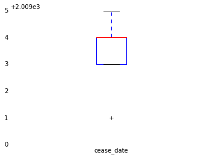

```python
boxplot_dete = dete_survey_updated.boxplot(column=['cease_date'], grid=False)
boxplot_dete.set_ylim(2009,2014)
boxplot_dete.tick_params(bottom='off', top='off', left='off', right='off')

for key, spine in boxplot_dete.spines.items():
    spine.set_visible(False)
```

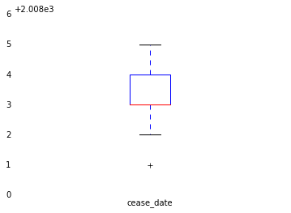

```python
boxplot_tafe = tafe_survey_updated.boxplot(column=['cease_date'], grid=False)
boxplot_tafe.set_ylim(2008, 2014)
boxplot_tafe.tick_params(top='off', bottom='off', left='off', right='off')

for key, spine in boxplot_tafe.spines.items():
    spine.set_visible(False)
```

#### We were further cleaning and analyzing our core cols in both our Dataset's (*cease_date*) and other cols in the DETE DS such as *dete_start_date*.

#### We cleaned the data and extracted only the year, and also converted the data to a numeric type(float), in order to better work with it.

#### We concluded that apart from this, there were no need to futher modify the Data. The datapoints seem to be correct and rather realistic. The *cease_date* in the DETE Dataset evolves around the years 2006-2014. While in the TAFE is between 2009-2013

### Standardizing the time spent in both institutes.

```python
dete_survey_updated['institute_service'] = dete_survey_updated['cease_date']-dete_survey_updated['dete_start_date']
```

```python
dete_survey_updated.head()
```

|  | id | separationtype | cease_date | dete_start_date | role_start_date | position | classification | region | business_unit | employment_status | ... | workload | none_of_the_above | gender | age | aboriginal | torres_strait | south_sea | disability | nesb | institute_service |
| --- | --- | --- | --- | --- | --- | --- | --- | --- | --- | --- | --- | --- | --- | --- | --- | --- | --- | --- | --- | --- | --- |
| 3 | 4 | Resignation-Other reasons | 2012.0 | 2005.0 | 2006.0 | Teacher | Primary | Central Queensland | NaN | Permanent Full-time | ... | False | False | Female | 36-40 | NaN | NaN | NaN | NaN | NaN | 7.0 |
| 5 | 6 | Resignation-Other reasons | 2012.0 | 1994.0 | 1997.0 | Guidance Officer | NaN | Central Office | Education Queensland | Permanent Full-time | ... | False | False | Female | 41-45 | NaN | NaN | NaN | NaN | NaN | 18.0 |
| 8 | 9 | Resignation-Other reasons | 2012.0 | 2009.0 | 2009.0 | Teacher | Secondary | North Queensland | NaN | Permanent Full-time | ... | False | False | Female | 31-35 | NaN | NaN | NaN | NaN | NaN | 3.0 |
| 9 | 10 | Resignation-Other employer | 2012.0 | 1997.0 | 2008.0 | Teacher Aide | NaN | NaN | NaN | Permanent Part-time | ... | False | False | Female | 46-50 | NaN | NaN | NaN | NaN | NaN | 15.0 |
| 11 | 12 | Resignation-Move overseas/interstate | 2012.0 | 2009.0 | 2009.0 | Teacher | Secondary | Far North Queensland | NaN | Permanent Full-time | ... | False | False | Male | 31-35 | NaN | NaN | NaN | NaN | NaN | 3.0 |

5 rows × 36 columns

```python
dete_survey_updated['institute_service'].value_counts(dropna=False).sort_index(ascending=True)
```

```
 0.0     20
 1.0     22
 2.0     14
 3.0     20
 4.0     16
 5.0     23
 6.0     17
 7.0     13
 8.0      8
 9.0     14
 10.0     6
 11.0     4
 12.0     6
 13.0     8
 14.0     6
 15.0     7
 16.0     5
 17.0     6
 18.0     5
 19.0     3
 20.0     7
 21.0     3
 22.0     6
 23.0     4
 24.0     4
 25.0     2
 26.0     2
 27.0     1
 28.0     2
 29.0     1
 30.0     2
 31.0     1
 32.0     3
 33.0     1
 34.0     1
 35.0     1
 36.0     2
 38.0     1
 39.0     3
 41.0     1
 42.0     1
 49.0     1
NaN      38
Name: institute_service, dtype: int64
```

#### Created a new col in the DETE Dataset, *institute_service*, in order to standardize the information related to the time, in years, spent in the institute. This piece of information was in the TAFE DS so we needed to add it also to the DETE

### Trying to aggregate the info in the different Dissatisfaction cols in both Dataset's into one columns only.

```python
tafe_survey_updated['Contributing Factors. Dissatisfaction'].value_counts(
dropna=False)
```

```
-                                         277
Contributing Factors. Dissatisfaction      55
NaN                                         8
Name: Contributing Factors. Dissatisfaction, dtype: int64
```

```python
tafe_survey_updated['Contributing Factors. Job Dissatisfaction'].value_counts(
dropna=False)
```

```
-                      270
Job Dissatisfaction     62
NaN                      8
Name: Contributing Factors. Job Dissatisfaction, dtype: int64
```

```python
def update_vals(element):
    if element == '-':
        return False
    elif pd.isnull(element):
        return np.nan
    else:
        return True


tafe_survey_updated[['Contributing Factors. Job Dissatisfaction',
                     'Contributing Factors. Dissatisfaction']] = tafe_survey_updated[['Contributing Factors. Job Dissatisfaction',
                     'Contributing Factors. Dissatisfaction']].applymap(
    update_vals)
```

```python
# Checking if the function update_vals and the process ran smoothly:
tafe_survey_updated['Contributing Factors. Job Dissatisfaction'].value_counts(
    dropna=False)
```

```
False    270
True      62
NaN        8
Name: Contributing Factors. Job Dissatisfaction, dtype: int64
```

```python
# Checking if the function update_vals and the process ran smoothly:
tafe_survey_updated['Contributing Factors. Dissatisfaction'].value_counts(
dropna=False)
```

```
False    277
True      55
NaN        8
Name: Contributing Factors. Dissatisfaction, dtype: int64
```

```python
# creating a new col, dissatisfied, in TAFE dataset:
tafe_survey_updated['dissatisfied'] = tafe_survey_updated[['Contributing Factors. Job Dissatisfaction',
                     'Contributing Factors. Dissatisfaction']].any(
axis=1, skipna=False)
```

```python
# copying and creating a new DF, tafe_resignations_up, from tafe_survey_updated:
tafe_resignations_up = tafe_survey_updated.copy()
```

```python
tafe_resignations_up.head()
```

|  | id | Institute | WorkArea | cease_date | separationtype | Contributing Factors. Career Move - Public Sector | Contributing Factors. Career Move - Private Sector | Contributing Factors. Career Move - Self-employment | Contributing Factors. Ill Health | Contributing Factors. Maternity/Family | ... | Contributing Factors. Travel | Contributing Factors. Other | Contributing Factors. NONE | gender | age | employment_status | position | institute_service | role_service | dissatisfied |
| --- | --- | --- | --- | --- | --- | --- | --- | --- | --- | --- | --- | --- | --- | --- | --- | --- | --- | --- | --- | --- | --- |
| 3 | 6.341399e+17 | Mount Isa Institute of TAFE | Non-Delivery (corporate) | 2010.0 | Resignation | - | - | - | - | - | ... | Travel | - | - | NaN | NaN | NaN | NaN | NaN | NaN | False |
| 4 | 6.341466e+17 | Southern Queensland Institute of TAFE | Delivery (teaching) | 2010.0 | Resignation | - | Career Move - Private Sector | - | - | - | ... | - | - | - | Male | 41 45 | Permanent Full-time | Teacher (including LVT) | 3-4 | 3-4 | False |
| 5 | 6.341475e+17 | Southern Queensland Institute of TAFE | Delivery (teaching) | 2010.0 | Resignation | - | - | - | - | - | ... | - | Other | - | Female | 56 or older | Contract/casual | Teacher (including LVT) | 7-10 | 7-10 | False |
| 6 | 6.341520e+17 | Barrier Reef Institute of TAFE | Non-Delivery (corporate) | 2010.0 | Resignation | - | Career Move - Private Sector | - | - | Maternity/Family | ... | - | Other | - | Male | 20 or younger | Temporary Full-time | Administration (AO) | 3-4 | 3-4 | False |
| 7 | 6.341537e+17 | Southern Queensland Institute of TAFE | Delivery (teaching) | 2010.0 | Resignation | - | - | - | - | - | ... | - | Other | - | Male | 46 50 | Permanent Full-time | Teacher (including LVT) | 3-4 | 3-4 | False |

5 rows × 24 columns

```python
dete_dissatisfaction_cols = ['job_dissatisfaction', 'dissatisfaction_with_the_department',
                            'physical_work_environment', 'lack_of_recognition',
                            'lack_of_job_security', 'work_location',
                            'employment_conditions', 'work_life_balance',
                            'workload']
dete_survey_updated['dissatisfied'] =  dete_survey_updated[dete_dissatisfaction_cols].any(
axis=1, skipna=False)
```

```python
# copying and creating a new DF, dete_resignations_up, from dete_survey_updated:
dete_resignations_up = dete_survey_updated.copy()
```

```python
dete_resignations_up.head()
```

|  | id | separationtype | cease_date | dete_start_date | role_start_date | position | classification | region | business_unit | employment_status | ... | none_of_the_above | gender | age | aboriginal | torres_strait | south_sea | disability | nesb | institute_service | dissatisfied |
| --- | --- | --- | --- | --- | --- | --- | --- | --- | --- | --- | --- | --- | --- | --- | --- | --- | --- | --- | --- | --- | --- |
| 3 | 4 | Resignation-Other reasons | 2012.0 | 2005.0 | 2006.0 | Teacher | Primary | Central Queensland | NaN | Permanent Full-time | ... | False | Female | 36-40 | NaN | NaN | NaN | NaN | NaN | 7.0 | False |
| 5 | 6 | Resignation-Other reasons | 2012.0 | 1994.0 | 1997.0 | Guidance Officer | NaN | Central Office | Education Queensland | Permanent Full-time | ... | False | Female | 41-45 | NaN | NaN | NaN | NaN | NaN | 18.0 | True |
| 8 | 9 | Resignation-Other reasons | 2012.0 | 2009.0 | 2009.0 | Teacher | Secondary | North Queensland | NaN | Permanent Full-time | ... | False | Female | 31-35 | NaN | NaN | NaN | NaN | NaN | 3.0 | False |
| 9 | 10 | Resignation-Other employer | 2012.0 | 1997.0 | 2008.0 | Teacher Aide | NaN | NaN | NaN | Permanent Part-time | ... | False | Female | 46-50 | NaN | NaN | NaN | NaN | NaN | 15.0 | True |
| 11 | 12 | Resignation-Move overseas/interstate | 2012.0 | 2009.0 | 2009.0 | Teacher | Secondary | Far North Queensland | NaN | Permanent Full-time | ... | False | Male | 31-35 | NaN | NaN | NaN | NaN | NaN | 3.0 | False |

5 rows × 37 columns

#### We just compiled all the info that was related to the dissatisfaction motives into one single column, *dissatisfied*. And sorted it by True of False. So if an employee had any of the innumerous dissatisfaction reasons pinned as True it felt into the True category of the newly created col *dissatisfied*

### Now its time to combine both Dataset's into one.

```python
# creating a new col to identify the rows that belong to the DETE DS:
dete_resignations_up['institute'] = 'DETE'
dete_resignations_up.head()
```

|  | id | separationtype | cease_date | dete_start_date | role_start_date | position | classification | region | business_unit | employment_status | ... | gender | age | aboriginal | torres_strait | south_sea | disability | nesb | institute_service | dissatisfied | institute |
| --- | --- | --- | --- | --- | --- | --- | --- | --- | --- | --- | --- | --- | --- | --- | --- | --- | --- | --- | --- | --- | --- |
| 3 | 4 | Resignation-Other reasons | 2012.0 | 2005.0 | 2006.0 | Teacher | Primary | Central Queensland | NaN | Permanent Full-time | ... | Female | 36-40 | NaN | NaN | NaN | NaN | NaN | 7.0 | False | DETE |
| 5 | 6 | Resignation-Other reasons | 2012.0 | 1994.0 | 1997.0 | Guidance Officer | NaN | Central Office | Education Queensland | Permanent Full-time | ... | Female | 41-45 | NaN | NaN | NaN | NaN | NaN | 18.0 | True | DETE |
| 8 | 9 | Resignation-Other reasons | 2012.0 | 2009.0 | 2009.0 | Teacher | Secondary | North Queensland | NaN | Permanent Full-time | ... | Female | 31-35 | NaN | NaN | NaN | NaN | NaN | 3.0 | False | DETE |
| 9 | 10 | Resignation-Other employer | 2012.0 | 1997.0 | 2008.0 | Teacher Aide | NaN | NaN | NaN | Permanent Part-time | ... | Female | 46-50 | NaN | NaN | NaN | NaN | NaN | 15.0 | True | DETE |
| 11 | 12 | Resignation-Move overseas/interstate | 2012.0 | 2009.0 | 2009.0 | Teacher | Secondary | Far North Queensland | NaN | Permanent Full-time | ... | Male | 31-35 | NaN | NaN | NaN | NaN | NaN | 3.0 | False | DETE |

5 rows × 38 columns

```python
# creating a new col to identify the rows that belong to the TAFE DS:
tafe_resignations_up['institute'] = 'TAFE'
tafe_resignations_up.head()
```

|  | id | Institute | WorkArea | cease_date | separationtype | Contributing Factors. Career Move - Public Sector | Contributing Factors. Career Move - Private Sector | Contributing Factors. Career Move - Self-employment | Contributing Factors. Ill Health | Contributing Factors. Maternity/Family | ... | Contributing Factors. Other | Contributing Factors. NONE | gender | age | employment_status | position | institute_service | role_service | dissatisfied | institute |
| --- | --- | --- | --- | --- | --- | --- | --- | --- | --- | --- | --- | --- | --- | --- | --- | --- | --- | --- | --- | --- | --- |
| 3 | 6.341399e+17 | Mount Isa Institute of TAFE | Non-Delivery (corporate) | 2010.0 | Resignation | - | - | - | - | - | ... | - | - | NaN | NaN | NaN | NaN | NaN | NaN | False | TAFE |
| 4 | 6.341466e+17 | Southern Queensland Institute of TAFE | Delivery (teaching) | 2010.0 | Resignation | - | Career Move - Private Sector | - | - | - | ... | - | - | Male | 41 45 | Permanent Full-time | Teacher (including LVT) | 3-4 | 3-4 | False | TAFE |
| 5 | 6.341475e+17 | Southern Queensland Institute of TAFE | Delivery (teaching) | 2010.0 | Resignation | - | - | - | - | - | ... | Other | - | Female | 56 or older | Contract/casual | Teacher (including LVT) | 7-10 | 7-10 | False | TAFE |
| 6 | 6.341520e+17 | Barrier Reef Institute of TAFE | Non-Delivery (corporate) | 2010.0 | Resignation | - | Career Move - Private Sector | - | - | Maternity/Family | ... | Other | - | Male | 20 or younger | Temporary Full-time | Administration (AO) | 3-4 | 3-4 | False | TAFE |
| 7 | 6.341537e+17 | Southern Queensland Institute of TAFE | Delivery (teaching) | 2010.0 | Resignation | - | - | - | - | - | ... | Other | - | Male | 46 50 | Permanent Full-time | Teacher (including LVT) | 3-4 | 3-4 | False | TAFE |

5 rows × 25 columns

```python
# combining both Dataset's into a major one, combined, using the concat method:
combined = pd.concat([dete_resignations_up, tafe_resignations_up],
                     ignore_index=True, axis=0)
```

```python
combined.columns.value_counts()
```

```
interpersonal_conflicts                                1
dissatisfaction_with_the_department                    1
classification                                         1
business_unit                                          1
Contributing Factors. Dissatisfaction                  1
lack_of_job_security                                   1
torres_strait                                          1
institute                                              1
Contributing Factors. Career Move - Private Sector     1
employment_conditions                                  1
ill_health                                             1
career_move_to_private_sector                          1
role_service                                           1
id                                                     1
institute_service                                      1
Contributing Factors. Study                            1
role_start_date                                        1
Contributing Factors. Career Move - Public Sector      1
aboriginal                                             1
separationtype                                         1
work_location                                          1
Contributing Factors. Ill Health                       1
age                                                    1
career_move_to_public_sector                           1
Contributing Factors. Interpersonal Conflict           1
maternity/family                                       1
Contributing Factors. Career Move - Self-employment    1
none_of_the_above                                      1
workload                                               1
region                                                 1
relocation                                             1
dissatisfied                                           1
Contributing Factors. Other                            1
Contributing Factors. Job Dissatisfaction              1
physical_work_environment                              1
position                                               1
disability                                             1
Institute                                              1
employment_status                                      1
Contributing Factors. Maternity/Family                 1
traumatic_incident                                     1
work_life_balance                                      1
cease_date                                             1
south_sea                                              1
study/travel                                           1
dete_start_date                                        1
nesb                                                   1
Contributing Factors. Travel                           1
gender                                                 1
job_dissatisfaction                                    1
lack_of_recognition                                    1
WorkArea                                               1
Contributing Factors. NONE                             1
dtype: int64
```

```python
# dropping cols with a number of less than 500 non null values:
combined_updated = combined.dropna(thresh=500, axis=1).copy()
```

```python
combined_updated.shape
```

```
(651, 10)
```

```python
combined_updated.head()
```

|  | age | cease_date | dissatisfied | employment_status | gender | id | institute | institute_service | position | separationtype |
| --- | --- | --- | --- | --- | --- | --- | --- | --- | --- | --- |
| 0 | 36-40 | 2012.0 | False | Permanent Full-time | Female | 4.0 | DETE | 7 | Teacher | Resignation-Other reasons |
| 1 | 41-45 | 2012.0 | True | Permanent Full-time | Female | 6.0 | DETE | 18 | Guidance Officer | Resignation-Other reasons |
| 2 | 31-35 | 2012.0 | False | Permanent Full-time | Female | 9.0 | DETE | 3 | Teacher | Resignation-Other reasons |
| 3 | 46-50 | 2012.0 | True | Permanent Part-time | Female | 10.0 | DETE | 15 | Teacher Aide | Resignation-Other employer |
| 4 | 31-35 | 2012.0 | False | Permanent Full-time | Male | 12.0 | DETE | 3 | Teacher | Resignation-Move overseas/interstate |

```python
combined_updated['institute_service'].value_counts(dropna=False)
```

```
NaN                   88
Less than 1 year      73
1-2                   64
3-4                   63
5-6                   33
11-20                 26
5.0                   23
1.0                   22
7-10                  21
0.0                   20
3.0                   20
6.0                   17
4.0                   16
2.0                   14
9.0                   14
7.0                   13
More than 20 years    10
8.0                    8
13.0                   8
15.0                   7
20.0                   7
14.0                   6
10.0                   6
12.0                   6
17.0                   6
22.0                   6
16.0                   5
18.0                   5
24.0                   4
11.0                   4
23.0                   4
19.0                   3
39.0                   3
21.0                   3
32.0                   3
25.0                   2
26.0                   2
36.0                   2
28.0                   2
30.0                   2
33.0                   1
38.0                   1
35.0                   1
34.0                   1
31.0                   1
49.0                   1
29.0                   1
27.0                   1
42.0                   1
41.0                   1
Name: institute_service, dtype: int64
```

#### We just changed our 2 Dataset's (DETE and TAFE) and merged it into a single one, *combined*.

#### We did so recurring to the concat method in a row level (axis=0), in order to preserve and combine the shared cols between the 2 DS's. We also did it because our focus is on the col *institute_service* and we wanted all the values from both DS's to be 'under' this col.

#### Some more cleaning was made in the *combined* Dataset arriving to the *combined_updated* DS. This was achieved by dropping the columns that didn't had at least 500 non noll values.

### Categorizing and 'bin' the range of values in the *institute_service* column. And adding an extra col - *service_cat* with that info to the *combined_updated* Dataset.

```python
# checking if the data type of the institute_service col
# is in a str/object type in order to work on it with
# vectorized str methods:
combined_updated['institute_service'].dtype
```

```
dtype('O')
```

```python
# cleaning and modifying some tricky datapoints in the Series
# the purpose is to then change the dtype of the col to a
# float type:
combined_updated['institute_service'] = combined_updated['institute_service'
                                                        ].str.replace(
    'Less than 1 year', '0').copy()
```

```python
combined_updated['institute_service'] = combined_updated['institute_service'
                                                        ].str.replace(
    'More than 20 years', '21').copy()
```

```python
combined_updated['institute_service'
                ] = combined_updated[
    'institute_service'].str.split('-').str.get(-1).copy()
```

```python
combined_updated['institute_service'].value_counts(dropna=False)
```

```
NaN    361
0       73
2       64
4       63
6       33
20      26
10      21
21      10
Name: institute_service, dtype: int64
```

```python
# changing again the data type of the col to a float:
combined_updated['institute_service'] = combined_updated[
    'institute_service'].astype('float').copy()
```

```python
combined_updated['institute_service'].dtype
```

```
dtype('float64')
```

```python
# creating our own function - map_service_years - that
# will let us categorized into 4 main categories - New;
# Experienced; Established; Veteran - the several number
# of years spent in the company that ranges from 0 to 21:
def map_service_years(element):
    if element < 3:
        return 'New'
    elif element >= 3 and element <= 6:
        return 'Experienced'
    elif element >= 7 and element <= 10:
        return 'Established'
    elif pd.isnull(element):
        return np.nan
    else:
        return 'Veteran'

# applying our function to a element-wise method -
# Series.apply() and copying the changes back to a new
# col named service_cat:
combined_updated['service_cat'] = combined_updated[
    'institute_service'].apply(map_service_years).copy()
```

```python
# validating the values/categories and checkin the new col:
combined_updated['service_cat'].value_counts(dropna=False)
```

```
NaN            361
New            137
Experienced     96
Veteran         36
Established     21
Name: service_cat, dtype: int64
```

#### We ended up with adding a new column, *service_cat*, with 4 categories to our Dataset.

#### This is a *sine qua non* operation to tackle our questions. Without it, how could we answer the dissatisfaction on a time-spent-working level?

### Doing our first piece of analysis - working on the *dissatisfied* col in order to answer questions such as: How many workers, in terms of percentage, fall into the category dissatisfied and how many don't.

```python
#checking how many and what kind of values populate our Series:
combined_updated['dissatisfied'].value_counts(
dropna=False)
```

```
False    403
True     240
NaN        8
Name: dissatisfied, dtype: int64
```

```python
# filling the 8 missing values in the dissatisfied column
# with the most common value that populates the Series,
# recurring to the fillna() method:
combined_updated['dissatisfied'] = combined_updated[
    'dissatisfied'
].fillna(combined_updated['dissatisfied'
                         ].value_counts().idxmax()).copy()

combined_updated['dissatisfied'].value_counts(
dropna=False)
```

```
False    411
True     240
Name: dissatisfied, dtype: int64
```

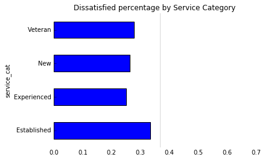

```python
#creating a pivot table from the aggregated col service_cat
#and with the values - mean - of the dissatisfied:
pivot_service_dissatisfied = combined_updated.pivot_table(
index=['service_cat'], values='dissatisfied')

#plotting that pivot table into a bar chart:
bar_chart = pivot_service_dissatisfied.plot(
kind='barh',
    title='Dissatisfied percentage by Service Category',
legend=False, xlim=(0,.7))

for key,spine in bar_chart.spines.items():
    spine.set_visible(False)

bar_chart.tick_params(top='off', bottom='off', right='off')

bar_chart.axvline(x=combined_updated[
    'dissatisfied'].mean(),color='grey', alpha=.3)

plt.show()
```